# Assignment

## Prediction Assignment

### Synopsis

The goal of this project is to predict the manner in which they did the exercise. This is the “classe” variable in the training set.

### Loading and preprocessing the data

Training Dataset: [Training Data](https://d396qusza40orc.cloudfront.net/predmachlearn/pml-training.csv) Testing Dataset: [Testing Data](https://d396qusza40orc.cloudfront.net/predmachlearn/pml-testing.csv)

Load libraries

```r
library(lubridate)
library(dplyr)
```

```r
library(ggplot2)
library(lattice)
library(caret)
library(randomForest)
```

Download training and test data

```r
train_url <- "https://d396qusza40orc.cloudfront.net/predmachlearn/pml-training.csv"
train_file <- "training.csv"
if (!file.exists(train_file)) {
  download.file(train_url, train_file, method="curl")
}
test_url <- "https://d396qusza40orc.cloudfront.net/predmachlearn/pml-testing.csv"
test_file <- "testing.csv"
if (!file.exists(test_file)) {
  download.file(test_url, test_file, method="curl")
}
```

Load the datasets

```r
training <- read.csv(train_file)
testing <- read.csv(test_file)
```

Let’s see how many variables and observations are included

```r
dim(training)
```

```
## [1] 19622   160
```

```r
dim(testing)
```

```
## [1]  20 160
```

#### Cleaning Data

I see 160 variables, many of which have NAs. Many variables are not needed. Lets create another dataframe with only relevant variables.

```r
# remove the first 7 variables as they are not relevant for classification.
training2 <- training[ , -(1:7)]
testing2 <- testing[ , -(1:7)]

unique(colSums(is.na(training2))/nrow(training2))
```

```
## [1] 0.0000000 0.9793089
```

```r
# Remove variables with no information
valid_cols <- colSums(is.na(training2)/dim(training2)) == 0
training2 <- training2[, valid_cols]
# Same for testing data
testing2 <- testing2[, valid_cols]

# Remove empty char columns
valid_cols <- colSums(training2 == "") == 0
training2 <- training2[, valid_cols]
# Same for testing data
testing2 <- testing2[, valid_cols]

dim(training2)
```

```
## [1] 19622    53
```

Testing2 should have the same # of variables

```r
dim(testing2)
```

```
## [1] 20 53
```

### Split data for validation with multiple models

My goal is to evaluate at-least two models so lets split the training set into train and validate subsets

```r
# Need reproducible split
set.seed(325)
inTrain <- createDataPartition(training2$classe, p=0.75, list=FALSE)

training <- training2[inTrain, ]
validation <- training2[-inTrain, ]

dim(training)
```

```
## [1] 14718    53
```

```r
dim(validation)
```

```
## [1] 4904   53
```

### Train model using Random Forest Model

```r
train_control <- trainControl(method="cv", 5)
mod_rf <- train(classe ~ ., method="rf", data=training, trControl=train_control)

mod_rf
```

```
## Random Forest
##
## 14718 samples
##    52 predictor
##     5 classes: 'A', 'B', 'C', 'D', 'E'
##
## No pre-processing
## Resampling: Cross-Validated (5 fold)
## Summary of sample sizes: 11776, 11775, 11774, 11773, 11774
## Resampling results across tuning parameters:
##
##   mtry  Accuracy   Kappa
##    2    0.9907596  0.9883107
##   27    0.9915747  0.9893417
##   52    0.9869544  0.9834972
##
## Accuracy was used to select the optimal model using the largest value.
## The final value used for the model was mtry = 27.
```

### Plot the variable Importance

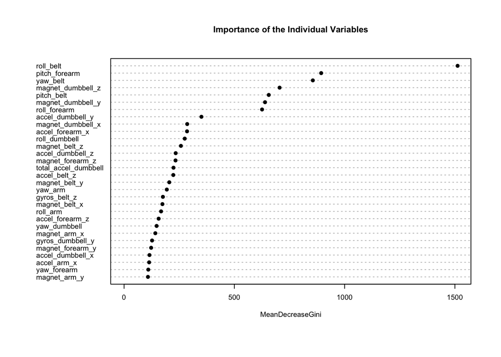

```r
varImpPlot(mod_rf$finalModel, sort = TRUE, pch = 19, col = 1, cex = 0.6,
           main = "Importance of the Individual Variables")
```

### Check the error rate of model for validation data

```r
valid_pred <- predict(mod_rf, validation)
confusionMatrix(as.factor(validation$classe), valid_pred)
```

```
## Confusion Matrix and Statistics
##
##           Reference
## Prediction    A    B    C    D    E
##          A 1395    0    0    0    0
##          B   11  937    1    0    0
##          C    0    0  849    6    0
##          D    0    0    6  797    1
##          E    0    0    2    4  895
##
## Overall Statistics
##
##                Accuracy : 0.9937
##                  95% CI : (0.991, 0.9957)
##     No Information Rate : 0.2867
##     P-Value [Acc > NIR] : < 2.2e-16
##
##                   Kappa : 0.992
##
##  Mcnemar's Test P-Value : NA
##
## Statistics by Class:
##
##                      Class: A Class: B Class: C Class: D Class: E
## Sensitivity            0.9922   1.0000   0.9895   0.9876   0.9989
## Specificity            1.0000   0.9970   0.9985   0.9983   0.9985
## Pos Pred Value         1.0000   0.9874   0.9930   0.9913   0.9933
## Neg Pred Value         0.9969   1.0000   0.9978   0.9976   0.9998
## Prevalence             0.2867   0.1911   0.1750   0.1646   0.1827
## Detection Rate         0.2845   0.1911   0.1731   0.1625   0.1825
## Detection Prevalence   0.2845   0.1935   0.1743   0.1639   0.1837
## Balanced Accuracy      0.9961   0.9985   0.9940   0.9929   0.9987
```

We see that model accuracy is 99.3% for validation data.

We also see that following variables have the most impact on the model. - roll_best - pitch_forearm - yaw_belt - magnet_dumbbell_z - pitch_belt - magnet_dumbbell_y - roll_forearm

Lets prune the model to focus only on these imp variable. We can recheck the affect on accuracy.

```r
imp_cols <- c("roll_belt", "pitch_forearm", "yaw_belt", "magnet_dumbbell_z",
               "pitch_belt", "magnet_dumbbell_y", "roll_forearm")
imp_train <- training[ ,imp_cols]
imp_train$classe <- training$classe

imp_valid <- validation[ ,imp_cols]
imp_valid$classe <- validation$classe

imp_test <- testing2[ ,imp_cols]
imp_test$problem_id <- testing2$problem_id

imp_model_rf <- train(classe ~ ., method="rf", data=imp_train, trControl=train_control)

imp_model_rf
```

```
## Random Forest
##
## 14718 samples
##     7 predictor
##     5 classes: 'A', 'B', 'C', 'D', 'E'
##
## No pre-processing
## Resampling: Cross-Validated (5 fold)
## Summary of sample sizes: 11774, 11775, 11775, 11773, 11775
## Resampling results across tuning parameters:
##
##   mtry  Accuracy   Kappa
##   2     0.9828782  0.9783503
##   4     0.9826062  0.9780066
##   7     0.9790049  0.9734499
##
## Accuracy was used to select the optimal model using the largest value.
## The final value used for the model was mtry = 2.
```

Note that model accuracy is still 98.2%. Lets check the error rate of this (hopefully) compressed model. ### Check the error rate of model for validation data

```r
valid_pred <- predict(imp_model_rf, imp_valid)
confusionMatrix(as.factor(imp_valid$classe), valid_pred)
```

```
## Confusion Matrix and Statistics
##
##           Reference
## Prediction    A    B    C    D    E
##          A 1387    5    2    1    0
##          B    7  933    7    2    0
##          C    2    5  842    6    0
##          D    0    1    0  803    0
##          E    0    5    1    3  892
##
## Overall Statistics
##
##                Accuracy : 0.9904
##                  95% CI : (0.9873, 0.9929)
##     No Information Rate : 0.2847
##     P-Value [Acc > NIR] : < 2.2e-16
##
##                   Kappa : 0.9879
##
##  Mcnemar's Test P-Value : NA
##
## Statistics by Class:
##
##                      Class: A Class: B Class: C Class: D Class: E
## Sensitivity            0.9936   0.9831   0.9883   0.9853   1.0000
## Specificity            0.9977   0.9960   0.9968   0.9998   0.9978
## Pos Pred Value         0.9943   0.9831   0.9848   0.9988   0.9900
## Neg Pred Value         0.9974   0.9960   0.9975   0.9971   1.0000
## Prevalence             0.2847   0.1935   0.1737   0.1662   0.1819
## Detection Rate         0.2828   0.1903   0.1717   0.1637   0.1819
## Detection Prevalence   0.2845   0.1935   0.1743   0.1639   0.1837
## Balanced Accuracy      0.9956   0.9895   0.9925   0.9925   0.9989
```

### Predict the test data

Now lets predict the test data

```r
test_pred <- predict(mod_rf, newdata=testing2)
```

### Results

The testing data is predicted as follows. The model has an accuracy of 99.3%.

```r
test_pred
```

```
##  [1] B A B A A E D B A A B C B A E E A B B B
## Levels: A B C D E
```